# ANOVA

2025-05-28

We had a look at how ANOVA can be used to compare multiple groups at once. Now it is time for you to try

- Replace _ to complete expressions and return the correct answer
- Restart R to remove previous results using: Ctrl/Cmd + shift + F10
- Remember - try to use google to help you answer questions

> Remember to change eval = T at the top of the script, and in the extra exercises

## Import packages

Import the `tidyverse` for `dplyr` and `ggplot2` packages

```r
library(tidyverse)
```

## One-way ANOVA

`Turtles.csv` is a study that examined the he hatching times of turtle eggs incubated at four different temperatures (15°C, 20°C, 25°C and 30°C). Hatching time (Days) is the continuous response variable and temperature is the categorical predictor variable with with four levels.

### Import the data

Import `Turtles.csv` from the `data/` folder

```r
turtle_hatching <-
  read_csv("data/Turtles.csv")
```

### Examine the data

Count the number of observations per temperature

- Confirm there are 4 temperature levels
- How many replicates are there per temperature? If they are all the same, we called this a ‘balanced design’

```r
turtle_hatching |>
  glimpse()
```

```
## Rows: 40
## Columns: 2
## $ Temperature <dbl> 15, 15, 15, 15, 15, 15, 15, 15, 15, 15, 20, 20, 20, 20, 20…
## $ Days        <dbl> 37, 43, 45, 54, 56, 65, 62, 73, 74, 75, 30, 31, 34, 35, 35…
```

```r
turtle_hatching %>%
  count(Temperature)
```

```
## # A tibble: 4 × 2
##   Temperature     n
##         <dbl> <int>
## 1          15    10
## 2          20    10
## 3          25    10
## 4          30    10
```

### Visualise data

Create a boxplot of days until hatching by temperature groups

- There should be 4 boxes.
- What data type is Temperature currently? We will fix it in the next step

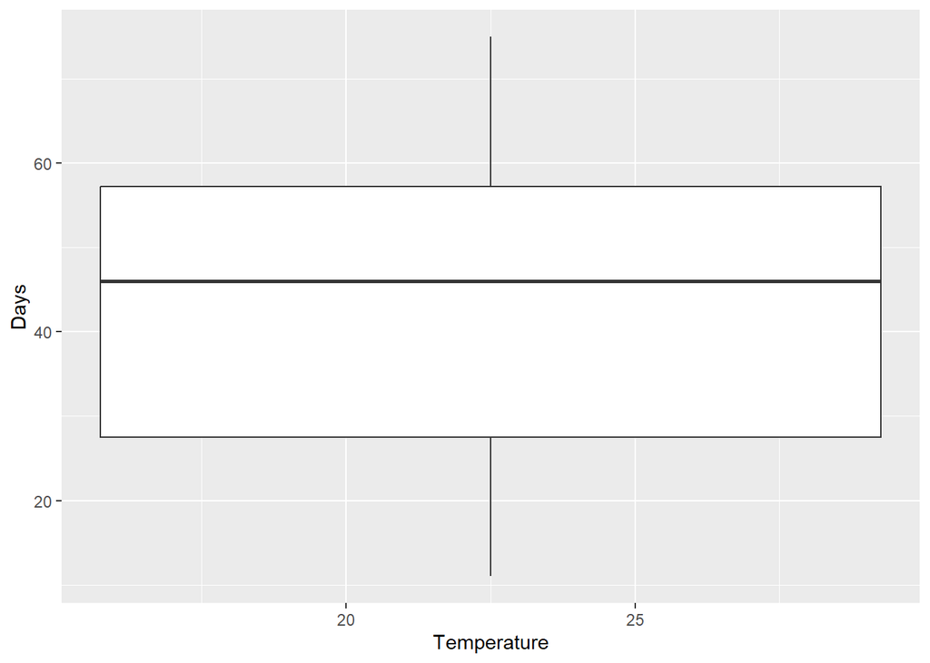

```r
turtle_hatching %>%
  ggplot(mapping = aes(x = Temperature, y = Days)) +
  geom_boxplot()
```

#### Data transformation

Turn Temperature into a factor using `mutate()` and `factor()`, then remake the boxplot (next section)

```r
turtle_hatching <-
  turtle_hatching %>%
  mutate(
    Temperature_f = factor(Temperature)
    )
```

#### Recreate the boxplot

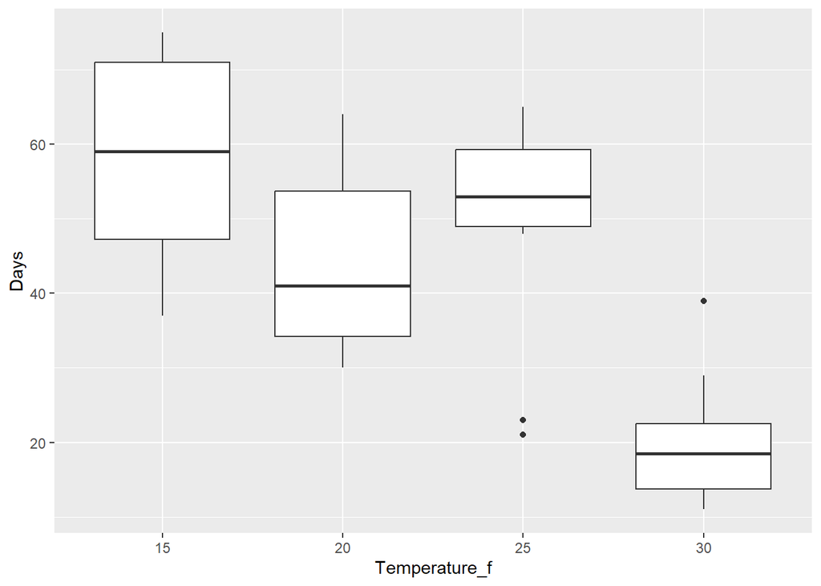

```r
turtle_hatching %>%
  ggplot(mapping = aes(x = Temperature_f, y = Days)) +
  geom_boxplot()
```

Export the plot to the outputs folder as a 120 x 120 mm .png

```r
ggsave(
  filename = "outputs/turtle-hatching-boxplots.png",
  width = 120, height = 120, units = "mm")
```

### Conduct an ANOVA

What is the null hypothesis here?

```
There is no difference in mean day of hatching between different incubation temperatures
```

Create an ANOVA object using `aov()`

- Remember to use a formula y ~ x and provide the data argument

```r
turtle_hatching_aov <-
  aov(Days ~ Temperature_f, data = turtle_hatching)
```

Obtain the traditional ANOVA table using `summary()`

```r
turtle_hatching_aov |>
  summary()
```

```
##               Df Sum Sq Mean Sq F value   Pr(>F)
## Temperature_f  3   8025  2675.2   15.98 9.08e-07 ***
## Residuals     36   6027   167.4
## ---
## Signif. codes:  0 '***' 0.001 '**' 0.01 '*' 0.05 '.' 0.1 ' ' 1
```

Is there a difference in hatching time between the 4 temperatures tested?

```
There is a significant difference between days to hatching between temperature of incubation
```

### Conduct pairwise comparisons

Use `TukeyHSD()` to conduct pairwise comparisons. Which temperatures differed from each other?

```r
turtle_hatching_aov |>
  TukeyHSD()
```

```
##   Tukey multiple comparisons of means
##     95% family-wise confidence level
##
## Fit: aov(formula = Days ~ Temperature_f, data = turtle_hatching)
##
## $Temperature_f
##        diff       lwr        upr     p adj
## 20-15 -13.8 -29.38469   1.784689 0.0982694
## 25-15  -9.2 -24.78469   6.384689 0.3969971
## 30-15 -38.3 -53.88469 -22.715311 0.0000006
## 25-20   4.6 -10.98469  20.184689 0.8562615
## 30-20 -24.5 -40.08469  -8.915311 0.0008384
## 30-25 -29.1 -44.68469 -13.515311 0.0000785
```

Write a short conclusion paragraph

```
There is a shorter days to hatching for 30C compared with the other temperatures.
```

## Extra exercises

### One factor ANOVA - Bag strength

A paper manufacturer makes grocery bags. They are interested in increasing the tensile strength of their product. It is thought that strength is a function of the hardwood concentration in the pulp. An investigation is carried out to compare four levels of hardwood concentration: 5%, 10%, 15% and 20%. Six test specimens are made at each level and all 24 specimens are then tested in random order

```r
# Import data
# Note: I forgot to say the file name "bag_strength.csv"
bags <-
  readr::read_csv("data/bag_strength.csv")
bags |>
  glimpse()
```

```
## Rows: 24
## Columns: 2
## $ hardwood_conc_pct <dbl> 5, 10, 15, 20, 5, 10, 15, 20, 5, 10, 15, 20, 5, 10, …
## $ tensile_stgh_psi  <dbl> 7, 12, 14, 19, 8, 17, 18, 25, 15, 13, 19, 22, 11, 18…
```

```r
# Examine data and prepare
bags %>%
  count(hardwood_conc_pct)
```

```
## # A tibble: 4 × 2
##   hardwood_conc_pct     n
##               <dbl> <int>
## 1                 5     6
## 2                10     6
## 3                15     6
## 4                20     6
```

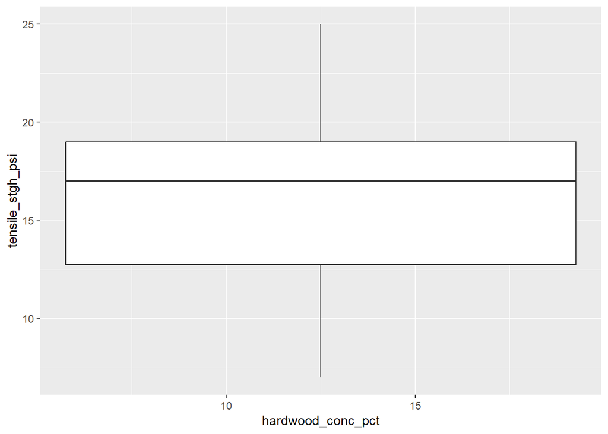

```r
bags %>%
  ggplot(aes(x = hardwood_conc_pct, y = tensile_stgh_psi)) +
  geom_boxplot()
```

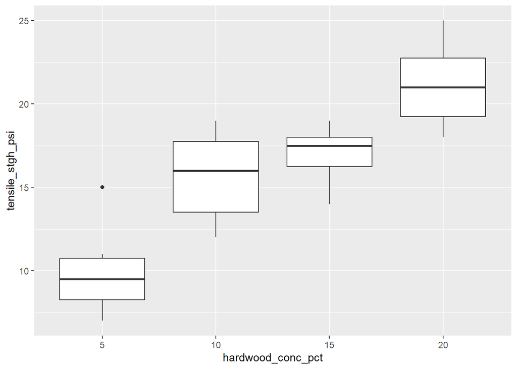

```r
bags <-
  bags %>%
  mutate(hardwood_conc_pct = factor(hardwood_conc_pct))

bags %>%
  ggplot(aes(x = hardwood_conc_pct, y = tensile_stgh_psi)) +
  geom_boxplot()
```

```r
# ANOVA
bags_aov <-
  aov(tensile_stgh_psi ~ hardwood_conc_pct, data = bags)

bags_aov %>%
  summary()
```

```
##                   Df Sum Sq Mean Sq F value   Pr(>F)
## hardwood_conc_pct  3  382.8  127.60   19.61 3.59e-06 ***
## Residuals         20  130.2    6.51
## ---
## Signif. codes:  0 '***' 0.001 '**' 0.01 '*' 0.05 '.' 0.1 ' ' 1
```

```r
# Pairwise comparisons
bags_aov %>%
  TukeyHSD()
```

```
##   Tukey multiple comparisons of means
##     95% family-wise confidence level
##
## Fit: aov(formula = tensile_stgh_psi ~ hardwood_conc_pct, data = bags)
##
## $hardwood_conc_pct
##            diff         lwr       upr     p adj
## 10-5   5.666667  1.54410408  9.789229 0.0051108
## 15-5   7.000000  2.87743741 11.122563 0.0006501
## 20-5  11.166667  7.04410408 15.289229 0.0000015
## 15-10  1.333333 -2.78922925  5.455896 0.8022275
## 20-10  5.500000  1.37743741  9.622563 0.0065966
## 20-15  4.166667  0.04410408  8.289229 0.0470251
```

```r
# Conclusion
# 20 > 15,10 > 5 in terms of tensile_stgh_psi
```

### Two factor ANOVA - Battery life

`battery_life.csv` contains data on battery life under different temperature and materials: The effective life (in hours) of batteries is compared by material type (1, 2 or 3) and operating temperature: Low (-10˚C), Medium (20˚C) or High (45˚C). Twelve batteries are randomly selected from each material type and are then randomly allocated to each temperature level.

```r
# Import battery_life.csv
battery_life <-
  readr::read_csv("data/battery_life.csv")
battery_life |>
  glimpse()
```

```
## Rows: 36
## Columns: 3
## $ temperature   <chr> "low_-10C", "low_-10C", "low_-10C", "med_20C", "med_20C"…
## $ material_type <dbl> 1, 2, 3, 1, 2, 3, 1, 2, 3, 1, 2, 3, 1, 2, 3, 1, 2, 3, 1,…
## $ life_h        <dbl> 130, 150, 138, 34, 136, 174, 20, 25, 96, 155, 188, 110, …
```

```r
# Examine data
battery_life %>%
  count(temperature, material_type)
```

```
## # A tibble: 9 × 3
##   temperature material_type     n
##   <chr>               <dbl> <int>
## 1 high_45C                1     4
## 2 high_45C                2     4
## 3 high_45C                3     4
## 4 low_-10C                1     4
## 5 low_-10C                2     4
## 6 low_-10C                3     4
## 7 med_20C                 1     4
## 8 med_20C                 2     4
## 9 med_20C                 3     4
```

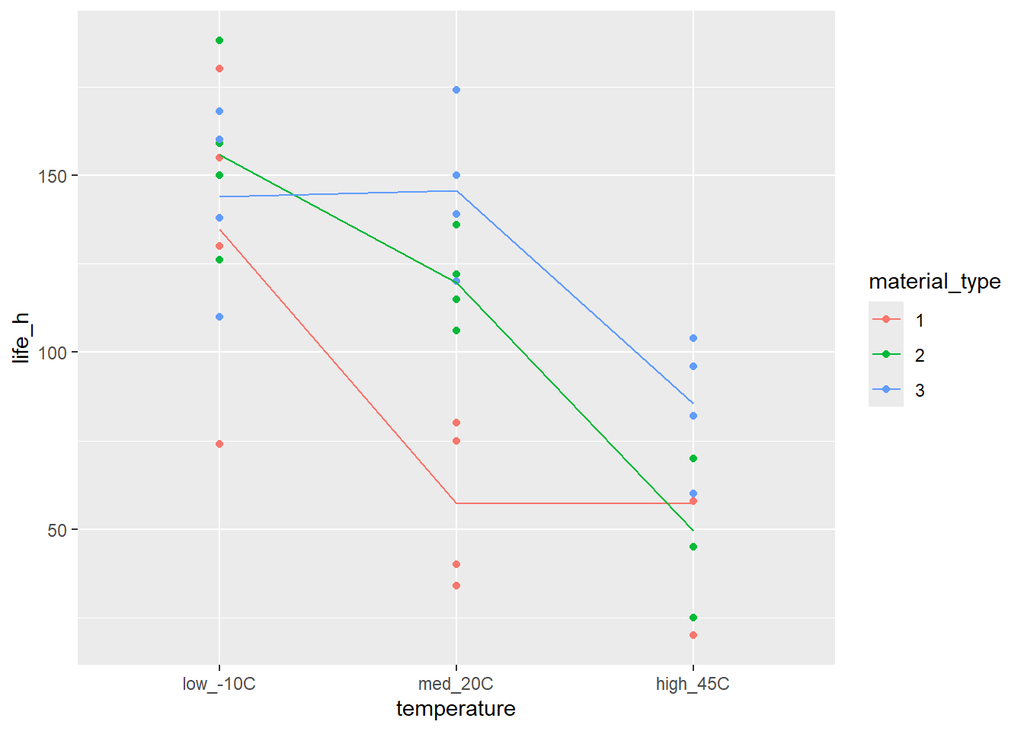

```r
# Prepare data
# material_type is numeric and needs to be a factor
# temperature requires used to specific the levels of the factor for low, med, high
battery_life <-
  battery_life %>%
  mutate(material_type = factor(material_type),
         temperature = factor(temperature , levels = c('low_-10C', 'med_20C', 'high_45C')))

# Plot data
battery_life %>%
  ggplot(aes(x=temperature, y = life_h, colour = material_type)) +
  geom_point() +
  stat_summary(mapping = aes(group = material_type), geom = 'line', fun = 'mean')
```

```r
# Conduct ANOVA
battery_aov <-
  aov(life_h ~ temperature * material_type, data = battery_life)

battery_aov %>%
  summary()
```

```
##                           Df Sum Sq Mean Sq F value   Pr(>F)
## temperature                2  39119   19559  28.968 1.91e-07 ***
## material_type              2  10684    5342   7.911  0.00198 **
## temperature:material_type  4   9614    2403   3.560  0.01861 *
## Residuals                 27  18231     675
## ---
## Signif. codes:  0 '***' 0.001 '**' 0.01 '*' 0.05 '.' 0.1 ' ' 1
```

```r
# Conduct pairwise comparisons
# Note there are many!!
TukeyHSD(battery_aov)
```

```
##   Tukey multiple comparisons of means
##     95% family-wise confidence level
##
## Fit: aov(formula = life_h ~ temperature * material_type, data = battery_life)
##
## $temperature
##                        diff        lwr       upr     p adj
## med_20C-low_-10C  -37.25000  -63.55234 -10.94766 0.0043788
## high_45C-low_-10C -80.66667 -106.96901 -54.36432 0.0000001
## high_45C-med_20C  -43.41667  -69.71901 -17.11432 0.0009787
##
## $material_type
##         diff       lwr      upr     p adj
## 2-1 25.16667 -1.135677 51.46901 0.0627571
## 3-1 41.91667 15.614323 68.21901 0.0014162
## 3-2 16.75000 -9.552344 43.05234 0.2717815
##
## $`temperature:material_type`
##                          diff         lwr        upr     p adj
## med_20C:1-low_-10C:1   -77.50 -139.323184 -15.676816 0.0065212
## high_45C:1-low_-10C:1  -77.25 -139.073184 -15.426816 0.0067471
## low_-10C:2-low_-10C:1   21.00  -40.823184  82.823184 0.9616404
## med_20C:2-low_-10C:1   -15.00  -76.823184  46.823184 0.9953182
## high_45C:2-low_-10C:1  -85.25 -147.073184 -23.426816 0.0022351
## low_-10C:3-low_-10C:1    9.25  -52.573184  71.073184 0.9998527
## med_20C:3-low_-10C:1    11.00  -50.823184  72.823184 0.9994703
## high_45C:3-low_-10C:1  -49.25 -111.073184  12.573184 0.2016535
## high_45C:1-med_20C:1     0.25  -61.573184  62.073184 1.0000000
## low_-10C:2-med_20C:1    98.50   36.676816 160.323184 0.0003449
## med_20C:2-med_20C:1     62.50    0.676816 124.323184 0.0460388
## high_45C:2-med_20C:1    -7.75  -69.573184  54.073184 0.9999614
## low_-10C:3-med_20C:1    86.75   24.926816 148.573184 0.0018119
## med_20C:3-med_20C:1     88.50   26.676816 150.323184 0.0014173
## high_45C:3-med_20C:1    28.25  -33.573184  90.073184 0.8281938
## low_-10C:2-high_45C:1   98.25   36.426816 160.073184 0.0003574
## med_20C:2-high_45C:1    62.25    0.426816 124.073184 0.0474675
## high_45C:2-high_45C:1   -8.00  -69.823184  53.823184 0.9999508
## low_-10C:3-high_45C:1   86.50   24.676816 148.323184 0.0018765
## med_20C:3-high_45C:1    88.25   26.426816 150.073184 0.0014679
## high_45C:3-high_45C:1   28.00  -33.823184  89.823184 0.8347331
## med_20C:2-low_-10C:2   -36.00  -97.823184  25.823184 0.5819453
## high_45C:2-low_-10C:2 -106.25 -168.073184 -44.426816 0.0001152
## low_-10C:3-low_-10C:2  -11.75  -73.573184  50.073184 0.9991463
## med_20C:3-low_-10C:2   -10.00  -71.823184  51.823184 0.9997369
## high_45C:3-low_-10C:2  -70.25 -132.073184  -8.426816 0.0172076
## high_45C:2-med_20C:2   -70.25 -132.073184  -8.426816 0.0172076
## low_-10C:3-med_20C:2    24.25  -37.573184  86.073184 0.9165175
## med_20C:3-med_20C:2     26.00  -35.823184  87.823184 0.8822881
## high_45C:3-med_20C:2   -34.25  -96.073184  27.573184 0.6420441
## low_-10C:3-high_45C:2   94.50   32.676816 156.323184 0.0006078
## med_20C:3-high_45C:2    96.25   34.426816 158.073184 0.0004744
## high_45C:3-high_45C:2   36.00  -25.823184  97.823184 0.5819453
## med_20C:3-low_-10C:3     1.75  -60.073184  63.573184 1.0000000
## high_45C:3-low_-10C:3  -58.50 -120.323184   3.323184 0.0742711
## high_45C:3-med_20C:3   -60.25 -122.073184   1.573184 0.0604247
```

```r
# With more advanced packages e.g. emmeans
# compare temperatures within a material,
# Or compare materials at specific temperatures
# exclude comparisons e.g. material 1 cold vs material 2 hott (no useful)
library(emmeans)
# Generally, battery life for 2 and 3 dropped at high temp
# 1 dropped at med temp
emmeans(battery_aov, specs = ~ temperature | material_type) |>
  contrast(method = 'pairwise')
```

```
## material_type = 1:
##  contrast              estimate   SE df t.ratio p.value
##  (low_-10C) - med_20C     77.50 18.4 27   4.218  0.0007
##  (low_-10C) - high_45C    77.25 18.4 27   4.204  0.0007
##  med_20C - high_45C       -0.25 18.4 27  -0.014  0.9999
##
## material_type = 2:
##  contrast              estimate   SE df t.ratio p.value
##  (low_-10C) - med_20C     36.00 18.4 27   1.959  0.1419
##  (low_-10C) - high_45C   106.25 18.4 27   5.783  <.0001
##  med_20C - high_45C       70.25 18.4 27   3.823  0.0020
##
## material_type = 3:
##  contrast              estimate   SE df t.ratio p.value
##  (low_-10C) - med_20C     -1.75 18.4 27  -0.095  0.9950
##  (low_-10C) - high_45C    58.50 18.4 27   3.184  0.0099
##  med_20C - high_45C       60.25 18.4 27   3.279  0.0078
##
## P value adjustment: tukey method for comparing a family of 3 estimates
```

```r
# At ow_-10C, not difference between material
# At med_20C, type 1 different to 2 and 3
# At high_45C, no difference between material, battery life all dropped
emmeans(battery_aov, specs = ~ material_type | temperature) |>
  contrast(method = 'pairwise')
```

```
## temperature = low_-10C:
##  contrast                        estimate   SE df t.ratio p.value
##  material_type1 - material_type2   -21.00 18.4 27  -1.143  0.4967
##  material_type1 - material_type3    -9.25 18.4 27  -0.503  0.8703
##  material_type2 - material_type3    11.75 18.4 27   0.639  0.7998
##
## temperature = med_20C:
##  contrast                        estimate   SE df t.ratio p.value
##  material_type1 - material_type2   -62.50 18.4 27  -3.402  0.0058
##  material_type1 - material_type3   -88.50 18.4 27  -4.817  0.0001
##  material_type2 - material_type3   -26.00 18.4 27  -1.415  0.3475
##
## temperature = high_45C:
##  contrast                        estimate   SE df t.ratio p.value
##  material_type1 - material_type2     8.00 18.4 27   0.435  0.9012
##  material_type1 - material_type3   -28.00 18.4 27  -1.524  0.2959
##  material_type2 - material_type3   -36.00 18.4 27  -1.959  0.1419
##
## P value adjustment: tukey method for comparing a family of 3 estimates
```